# Bio4158/Bio5158 - Report 3

- Show All Code
- Hide All Code
- View Source

Exercise

Author

Group 22 - Nalan Kurnaz

Published

October 8, 2025

# The problem

Climate has generally been observed to be warming but the extent of to which this is observed is highly variable across different geographic locations. Mechanistic models of human-induced climate change (i.e. that propose that climate change is caused by human activities) provide a potential explanation for this pattern (i.e. heterogeneity in warming among locations) as they predict that warming should be more prevalent in northern compared to more southerly locations. Curious as to whether data support this hypothesis, a student in Bio4158 accessed some of the historical temperature records available online.

# The data

Environment Canada provides monthly weather data for numerous stations located across Canada and can be accessed from the following website: http://climate.weather.gc.ca.

She randomly chose 3 cities from among the highest latitudes (Alert, NU; Mould Bay, NWT; and Sachs Harbour, NWT) and 3 from among the lowest latitudes (Windsor, ON; Yarmouth, NS; and Victoria, BC). Table 1 below summarizes the data sets that she downloaded from the Environment Canada website.

| Station Name | Province | Latitude | Longitude | Year Start | Year End |
| --- | --- | --- | --- | --- | --- |
| Victoria Gonzales HTS | BC | 48.41 | -123.33 | 1898 | 2004 |
| Alert | NU | 82.52 | -62.28 | 1950 | 2006 |
| Yarmouth | NS | 43.83 | -66.09 | 1940 | 2011 |
| Windsor A | ON | 42.28 | -82.96 | 1940 | 2011 |
| Mould Bay CS | NWT | 76.24 | -119.35 | 1948 | 2007 |
| Sachs Harbour A | NWT | 72 | -125.27 | 1955 | 2007 |

The data sets for each city ranged in dates, so she chose a period of time that was as complete as possible for all locations while still long enough to (hopefully) indicate climate trends. Based on the available data, 1950-2007 seemed to be the most appropriate time frame.

For the span of 1950-2007, she ended up with 4176 monthly observations. To simplify the analysis, she took averages of the mean temperature for each year and ended up with a total of 348 observations (174 in the North and 174 in the South). Taking the average over the whole year is justified because it normalizes the temperature for all seasons and for this reason most climate change analysis is done on mean annual temperatures rather than monthly values.

There were 36 NA values because not every year had a temperature value for every month. If some monthly data were missing from the year, **she decided to exclude the year** since taking the average temperature of only a few months could bias the average for that year.

Her final data set (`climate.csv`), which can be found on the course website, has the follwoing columns:

- `reg` : 0 = South, 1= North
- `Loc` : A=Alert, Y=Yarmouth, W=Windsor, M=Mould Bay, V=Victoria, S=Sachs Harbour
- `year`: Min= 1950, Max= 2007
- `ave` : Average monthly temperature in degrees Celsius

# The task

### Data Preprocessing

```r
# import necessary libraries
library(dplyr)
library(ggplot2)
library(pwr)
library(ggpmisc)
library(lmtest)
climate_data = read.csv("https://raw.githubusercontent.com/nalank1/r-files/refs/heads/main/data-bioxx58/climate.csv", header = TRUE, sep = ",", stringsAsFactors=TRUE)

sum(is.na(climate_data))
```

```
[1] 36
```

```r
newclimate_data <- climate_data[!is.na(climate_data$year), ]
summary(newclimate_data)
```

```
      reg      loc         year           ave
 Min.   :0.0   A:58   Min.   :1950   Min.   :-19.675
 1st Qu.:0.0   M:58   1st Qu.:1964   1st Qu.:-17.142
 Median :0.5   S:58   Median :1978   Median :  6.308
 Mean   :0.5   V:58   Mean   :1978   Mean   : -3.204
 3rd Qu.:1.0   W:58   3rd Qu.:1993   3rd Qu.:  9.117
 Max.   :1.0   Y:58   Max.   :2007   Max.   : 11.875
                                     NA's   :36
```

## 1.

What is the ‘biological’ (scientific) hypothesis? (1 point)

Human-induced climate change causes geographic variation in the rate of temperature change, with a higher rate of warming expected in northern Canada compared to southern Canada because melting snow and ice in the North cause the land and water to absorb more heat, which speeds up warming.

## 2.

What does this hypothesis predict in the context of her study? (2 points)

The northern stations (Alert, Mould Bay, Sachs Harbour) will have a greater increase in mean annual temperature over 1950-2007 compared to the southern stations (Victoria, Yarmouth, Windsor).

## 3.

What is the associated null hypothesis? (2 points)

The rate of change in temperatures in northern Canada will decrease or stay the same as the rate of change in mean annual temperature in the southern Canada.

## 4.

To test this hypothesis, the student will need to quantify the extent of any climate change separately for each location. She’s interested not only in the point estimate of the rate of climate change for each location (which she needs for testing her biological hypothesis above), but also in its significance in each location (i.e. she wants to separately test whether there is evidence that climate has changed in any way at each site). Let’s start by conducting a regression analysis to test whether there is evidence of climate change in **Yarmouth**.

### a.

What is the statistical null hypothesis relevant to the analysis ofthe Yarmouth data? (2 points)

The mean annual temperature in Yarmouth has not changed from 1950 to 2007.

### b.

What is the statistical model in ‘verbal’ form (e.g. dependent =independent + error) (1 point)

Temperature = Year + Error  
Independent Variable = Year  
Dependent Variable = Temperature

### c.

Provide a relevant plot of the Yarmouth data (2 points)

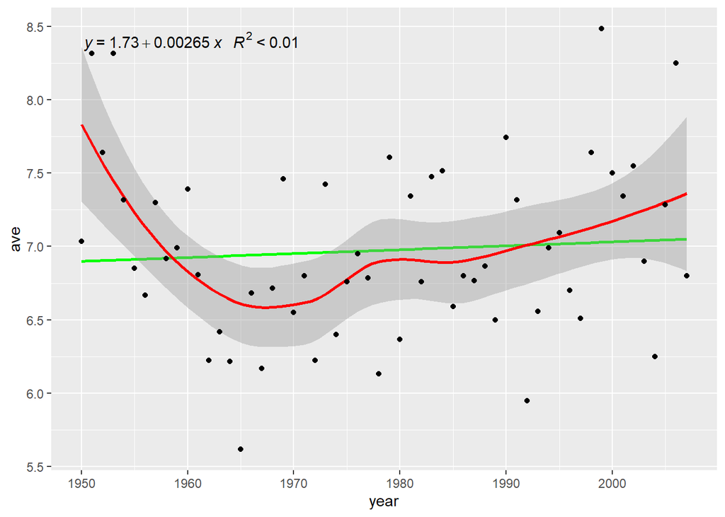

```r
yarmouth_data <- newclimate_data[newclimate_data$loc == "Y", ]

ggplot(yarmouth_data, aes(x = year, y = ave)) +
  geom_smooth(method = "lm", se = FALSE, color = "green") +
  geom_smooth( color = "red", se = TRUE) +
  geom_point() +
  stat_poly_eq(
    aes(label = paste(after_stat(eq.label), after_stat(rr.label), sep = "~~~")),
    formula = y ~ x, parse = TRUE
  )
```

The regression equation for Yarmouth data is Y = 1.73 + 0.00265X with R^2 < 0.01.

### d.

fit the model and provide its R output (1 point)

```r
RegModel.1 <- lm(ave ~ year, data = yarmouth_data)
summary(RegModel.1)
```

```
Call:
lm(formula = ave ~ year, data = yarmouth_data)

Residuals:
    Min      1Q  Median      3Q     Max
-1.3221 -0.4016 -0.1265  0.4505  1.4545

Coefficients:
            Estimate Std. Error t value Pr(>|t|)
(Intercept) 1.732995   9.466686   0.183    0.855
year        0.002649   0.004785   0.554    0.582

Residual standard error: 0.61 on 56 degrees of freedom
Multiple R-squared:  0.005445,  Adjusted R-squared:  -0.01231
F-statistic: 0.3066 on 1 and 56 DF,  p-value: 0.582
```

The multiple R-squared value is 0.005445.  
The f-statistic value is resulted to be 0.3066. The residual standard error for Yarmouth Data is 0.61 with 56 degrees of freedom. The adjusted R-squared value is -0.01231.

### e.

State the statistical assumptions for the analysis of the Yarmouth data and provide some evidence (plot, test, or statement) that you examined them (4 points)

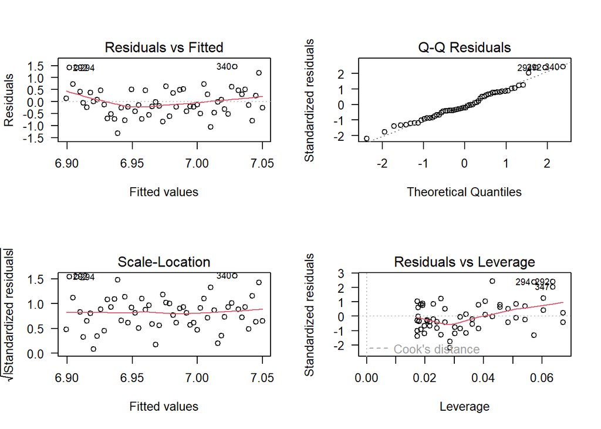

```r
par(mfrow = c(2,2), las = 1)
plot(RegModel.1)
```

```r
bptest(RegModel.1)
```

```
    studentized Breusch-Pagan test

data:  RegModel.1
BP = 0.23686, df = 1, p-value = 0.6265
```

```r
dwtest(RegModel.1)
```

```
    Durbin-Watson test

data:  RegModel.1
DW = 1.4933, p-value = 0.01735
alternative hypothesis: true autocorrelation is greater than 0
```

```r
resettest(RegModel.1)
```

```
    RESET test

data:  RegModel.1
RESET = 7.689, df1 = 2, df2 = 54, p-value = 0.001153
```

```r
shapiro.test(residuals(RegModel.1))
```

```
    Shapiro-Wilk normality test

data:  residuals(RegModel.1)
W = 0.97111, p-value = 0.1807
```

To have linear regression analysis, I conducted a series of diagnostic checks. The quadruple residual plot (plot(RegModel.1)) was used for an initial visual assessment.  
Breusch-Pagan Test (BP = 0.23686, p-value = 0.6265) confirmed homoscedasticity (constant variance of errors) by failing to reject the null hypothesis of constant variance  
The Shapiro-Wilk test (W = 0.97111, p-value = 0.1807) indicated that the residuals do not significantly deviate from normality.  
However, the Durbin-Watson test (DW = 1.4933, p-value = 0.01735) showed significant positive autocorrelation in the residuals, violating the independence assumption. The RESET Test (RESET = 7.689, p-value = 0.001153) displayed potential model misspecification, meaning the linear model may not be capable of capturing the relationship between year and temperature. Homoscedasticity and normality are met; however, the independence and linearity are not met.

### f.

What is the statistical conclusion (i.e. inference – do you accept or reject your null hypothesis) for Yarmouth? (2 points)

Based on the linear regression analysis, we fail to reject the null hypothesis that the mean annual temperature in Yarmouth has changed from 1950 to 2007. The regression model shows a non-significant relationship between year and temperature with coefficient p-value of 0.582. This is substantially greater than the standard alpha level 0.05, meaning that the observed slight positive trend (slope = 0.002649) is not statistically different from zero. The model’s overall lack of fit is also supported by an R-squared value of 0.005, meaning the year variable explains only 0.5% of the variation in temperature. Therefore, we fail to reject null hypothesis.

### g.

Provide a “biological” conclusion concerning climate change in Yarmouth (i.e. a qualified statement about climate change at this site including an estimate of raw effect size, its precision, and whether a trend of this magnitude matters) (3 points). To help you judge the latter, I suggest you consider that the Intergovernmental Panel on Climate Change (IPCC) concluded that dire consequences would result if temperature increased between 0.6 and 4 degrees over the next 100 years.

Based on the statistical analysis, the data from Yarmouth don’t provide strong evidence for a warming trend over the period 1950-2007. The model estimates a very slight increase in mean annual temperature of 0.0026°C per year (the slope). However, the precision of this estimate is low, as shown by the large standard error, resulting in a 95% confidence interval that most likely includes zero. When projected over a 100-year period, this trend equates to an estimated increase of 0.26°C. This magnitude of change falls at the very lowest end of the IPCC’s projected range of 0.6°C to 4.0°C. The estimated trend for Yarmouth is in the same direction as global climate change predictions; however, its projected magnitude over a 100-year period is less than half of the lower threshold the IPCC defines with impacts. This means that, based on the data we have, the observed warming trend will be minimal and its estimated impact would be small compared to global concerns.

### h.

Provide a statement about your confidence in the statistical conclusion (for example with respect to the violation of certain assumptions, to potential biases created by missing data, to suboptimal experimental design, and/or to power issues) (2 points)

```r
b <- coef(RegModel.1)[2]
std_error_slope <- coef(summary(RegModel.1))["year", "Std. Error"]

n <- nrow(yarmouth_data)
k <- 1 # for linear regression

d <- b / (std_error_slope * sqrt(n - k - 1))

power_result <- pwr.t.test(n = n, d = d, sig.level = 0.05, type = "one.sample")
power_result
```

```
     One-sample t test power calculation

              n = 58
              d = 0.07399208
      sig.level = 0.05
          power = 0.08584542
    alternative = two.sided
```

My confidence in the statistical conclusion is low, due to critically low statistical power and violations of model assumptions. A post-hoc power analysis shows that the data had 8% power with effect size = 0.07 to detect a trend, meaning there was 92% chance of failing to detect a true effect. This low power makes the non-significant result (p-value = 0.582) uninformative. Also, Durbin-Watson test (p-value = 0.017) and RESET Test (p = 0.001) violate model assumptions. While the data doesn’t show statistical significance, the limitations in power and model assumptions prevent any confident conclusion about temperature stability in Yarmouth. Therefore, we can’t really determine whether temperatures changed or not.

## 5.

Yarmouth is only one of the six locations for which she needs to quantify the extent of any climate change. Plot the temporal trend for temperature separately for each station (2 points), and estimate the rate of change for each station (2 points).

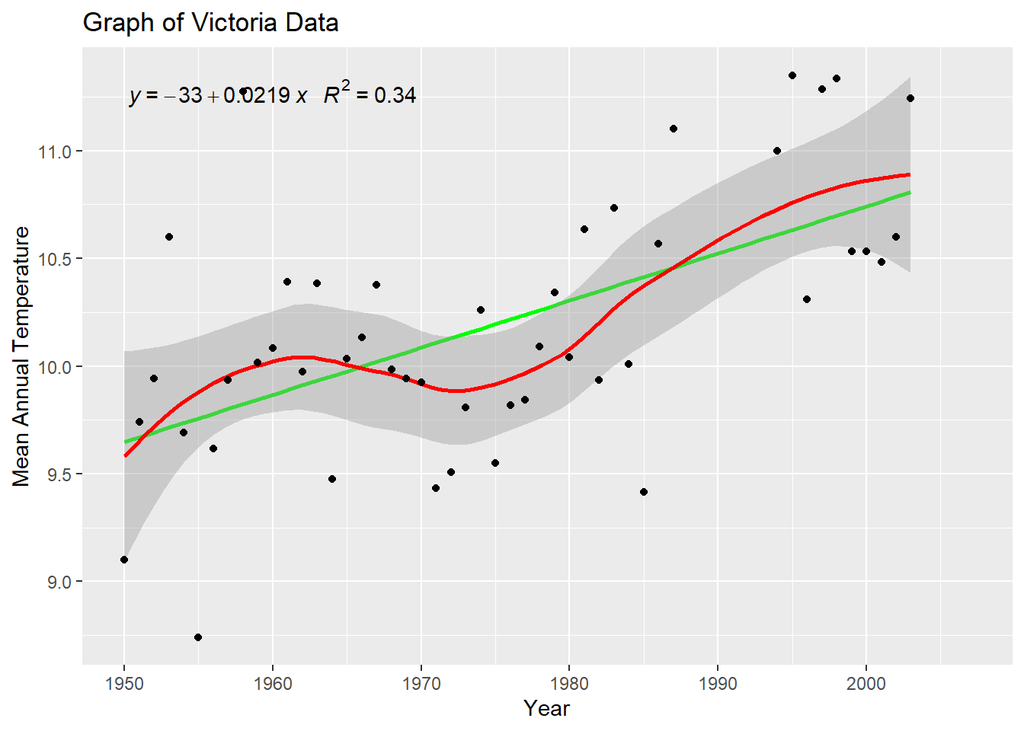

```r
victoria_data <- newclimate_data[newclimate_data$loc == "V", ]

ggplot(victoria_data, aes(x = year, y = ave)) +
  geom_smooth(method = "lm", se = FALSE, color = "green") +
  geom_smooth( color = "red", se = TRUE) +
  geom_point() +
  stat_poly_eq(
    aes(label = paste(after_stat(eq.label), after_stat(rr.label), sep = "~~~")),
    formula = y ~ x, parse = TRUE
  ) +
  labs(
    title = "Graph of Victoria Data",
    x = "Year",
    y = "Mean Annual Temperature"
  )
```

```r
RegModel.2 <- lm(ave ~ year, data = victoria_data)
summary(RegModel.2)
```

```
Call:
lm(formula = ave ~ year, data = victoria_data)

Residuals:
     Min       1Q   Median       3Q      Max
-1.01625 -0.34389  0.00619  0.31886  1.45149

Coefficients:
              Estimate Std. Error t value Pr(>|t|)
(Intercept) -32.989210   8.900702  -3.706 0.000563 ***
year          0.021866   0.004507   4.851 1.45e-05 ***
---
Signif. codes:  0 '***' 0.001 '**' 0.01 '*' 0.05 '.' 0.1 ' ' 1

Residual standard error: 0.4891 on 46 degrees of freedom
  (10 observations deleted due to missingness)
Multiple R-squared:  0.3385,    Adjusted R-squared:  0.3241
F-statistic: 23.54 on 1 and 46 DF,  p-value: 1.445e-05
```

```r
cat("Victoria Gonzales- Rate of change (slope):", coef(RegModel.2)[2], "\n")
```

```
Victoria Gonzales- Rate of change (slope): 0.02186554
```

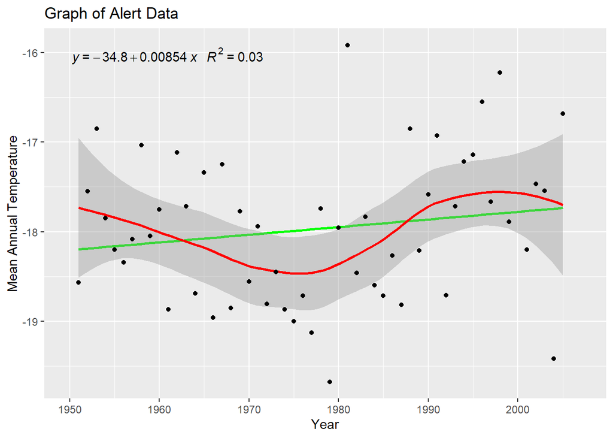

```r
alert_data <- newclimate_data[newclimate_data$loc == "A", ]

ggplot(alert_data, aes(x = year, y = ave)) +
  geom_smooth(method = "lm", se = FALSE, color = "green") +
  geom_smooth( color = "red", se = TRUE) +
  geom_point() +
  stat_poly_eq(
    aes(label = paste(after_stat(eq.label), after_stat(rr.label), sep = "~~~")),
    formula = y ~ x, parse = TRUE
  ) +
  labs(
    title = "Graph of Alert Data",
    x = "Year",
    y = "Mean Annual Temperature"
  )
```

```r
RegModel.3 <- lm(ave ~ year, data = alert_data)
summary(RegModel.3)
```

```
Call:
lm(formula = ave ~ year, data = alert_data)

Residuals:
     Min       1Q   Median       3Q      Max
-1.71880 -0.66672  0.06878  0.55264  2.02246

Coefficients:
              Estimate Std. Error t value Pr(>|t|)
(Intercept) -34.848697  13.998260  -2.490    0.016 *
year          0.008536   0.007078   1.206    0.233
---
Signif. codes:  0 '***' 0.001 '**' 0.01 '*' 0.05 '.' 0.1 ' ' 1

Residual standard error: 0.8184 on 52 degrees of freedom
  (4 observations deleted due to missingness)
Multiple R-squared:  0.02721,   Adjusted R-squared:  0.008499
F-statistic: 1.454 on 1 and 52 DF,  p-value: 0.2333
```

```r
cat("Alert - Rate of change (slope):", coef(RegModel.3)[2], "\n")
```

```
Alert - Rate of change (slope): 0.008535877
```

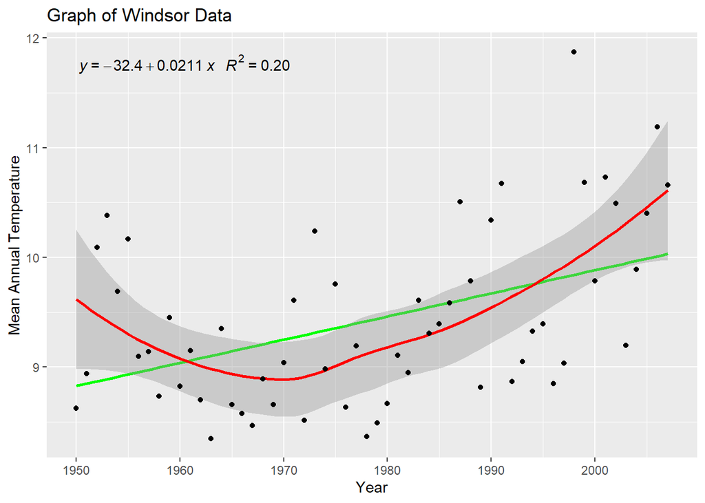

```r
windsor_data <- newclimate_data[newclimate_data$loc == "W", ]

ggplot(windsor_data, aes(x = year, y = ave)) +
  geom_smooth(method = "lm", se = FALSE, color = "green") +
  geom_smooth( color = "red", se = TRUE) +
  geom_point() +
  stat_poly_eq(
    aes(label = paste(after_stat(eq.label), after_stat(rr.label), sep = "~~~")),
    formula = y ~ x, parse = TRUE
  ) +
  labs(
    title = "Graph of Windsor Data",
    x = "Year",
    y = "Mean Annual Temperature"
  )
```

```r
RegModel.4 <- lm(ave ~ year, data = windsor_data)
summary(RegModel.4)
```

```
Call:
lm(formula = ave ~ year, data = windsor_data)

Residuals:
    Min      1Q  Median      3Q     Max
-1.0529 -0.5669 -0.1894  0.4264  2.0328

Coefficients:
              Estimate Std. Error t value Pr(>|t|)
(Intercept) -32.373595  11.082956  -2.921 0.005021 **
year          0.021129   0.005601   3.772 0.000392 ***
---
Signif. codes:  0 '***' 0.001 '**' 0.01 '*' 0.05 '.' 0.1 ' ' 1

Residual standard error: 0.7142 on 56 degrees of freedom
Multiple R-squared:  0.2026,    Adjusted R-squared:  0.1884
F-statistic: 14.23 on 1 and 56 DF,  p-value: 0.0003925
```

```r
cat("Windsor - Rate of change (slope):", coef(RegModel.4)[2], "\n")
```

```
Windsor - Rate of change (slope): 0.02112902
```

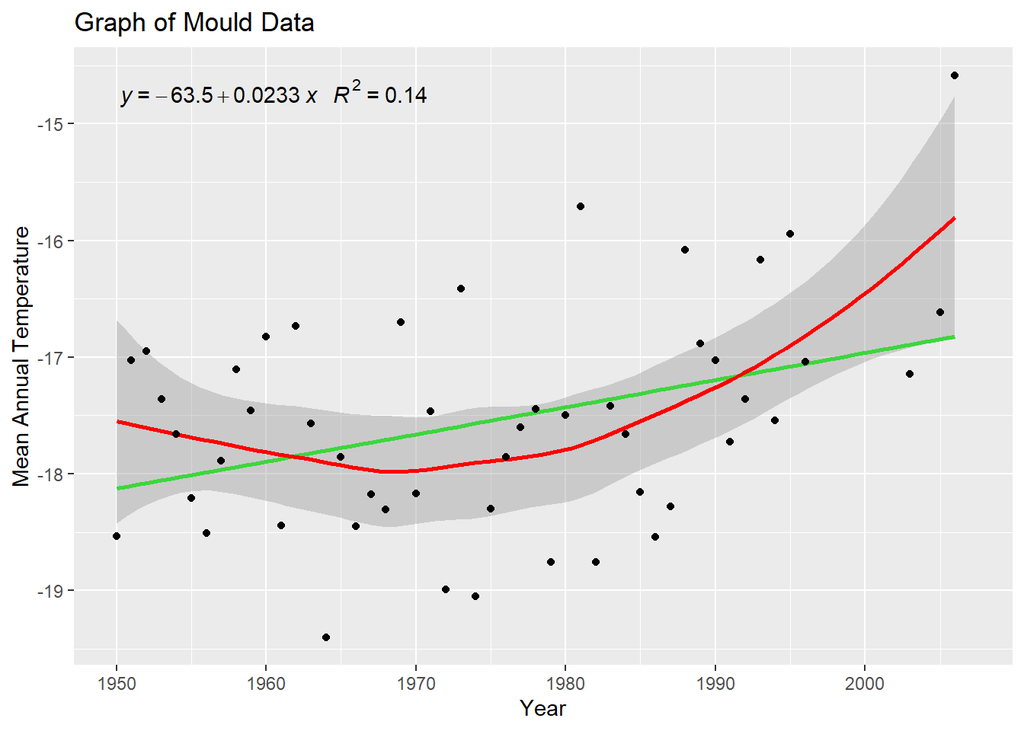

```r
mould_data <- newclimate_data[newclimate_data$loc == "M", ]

ggplot(mould_data, aes(x = year, y = ave)) +
  geom_smooth(method = "lm", se = FALSE, color = "green") +
  geom_smooth( color = "red", se = TRUE) +
  geom_point() +
  stat_poly_eq(
    aes(label = paste(after_stat(eq.label), after_stat(rr.label), sep = "~~~")),
    formula = y ~ x, parse = TRUE
  ) +
  labs(
    title = "Graph of Mould Data",
    x = "Year",
    y = "Mean Annual Temperature"
  )
```

```r
RegModel.5 <- lm(ave ~ year, data = mould_data)
summary(RegModel.5)
```

```
Call:
lm(formula = ave ~ year, data = mould_data)

Residuals:
     Min       1Q   Median       3Q      Max
-1.59938 -0.54513 -0.07645  0.63849  2.23938

Coefficients:
              Estimate Std. Error t value Pr(>|t|)
(Intercept) -63.529637  16.301850  -3.897 0.000301 ***
year          0.023284   0.008254   2.821 0.006946 **
---
Signif. codes:  0 '***' 0.001 '**' 0.01 '*' 0.05 '.' 0.1 ' ' 1

Residual standard error: 0.8844 on 48 degrees of freedom
  (8 observations deleted due to missingness)
Multiple R-squared:  0.1422,    Adjusted R-squared:  0.1243
F-statistic: 7.957 on 1 and 48 DF,  p-value: 0.006946
```

```r
cat("Mould Bay - Rate of change (slope):", coef(RegModel.5)[2], "\n")
```

```
Mould Bay - Rate of change (slope): 0.02328361
```

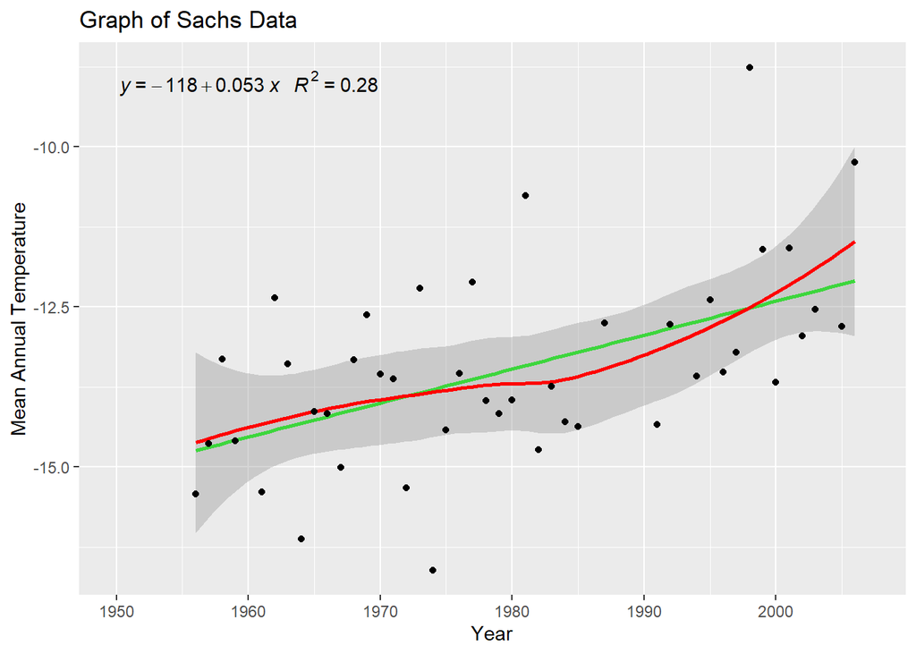

```r
sachs_data <- newclimate_data[newclimate_data$loc == "S", ]

ggplot(sachs_data, aes(x = year, y = ave)) +
  geom_smooth(method = "lm", se = FALSE, color = "green") +
  geom_smooth( color = "red", se = TRUE) +
  geom_point() +
  stat_poly_eq(
    aes(label = paste(after_stat(eq.label), after_stat(rr.label), sep = "~~~")),
    formula = y ~ x, parse = TRUE
  ) +
  labs(
    title = "Graph of Sachs Data",
    x = "Year",
    y = "Mean Annual Temperature"
  )
```

```r
RegModel.6 <- lm(ave ~ year, data = sachs_data)
summary(RegModel.6)
```

```
Call:
lm(formula = ave ~ year, data = sachs_data)

Residuals:
    Min      1Q  Median      3Q     Max
-2.8212 -0.8517 -0.1505  0.7746  3.7567

Coefficients:
            Estimate Std. Error t value Pr(>|t|)
(Intercept) -118.419     25.743  -4.600 3.86e-05 ***
year           0.053      0.013   4.077 0.000199 ***
---
Signif. codes:  0 '***' 0.001 '**' 0.01 '*' 0.05 '.' 0.1 ' ' 1

Residual standard error: 1.279 on 42 degrees of freedom
  (14 observations deleted due to missingness)
Multiple R-squared:  0.2835,    Adjusted R-squared:  0.2665
F-statistic: 16.62 on 1 and 42 DF,  p-value: 0.0001988
```

```r
cat("Sachs Harbour - Rate of change (slope):", coef(RegModel.6)[2], "\n")
```

```
Sachs Harbour - Rate of change (slope): 0.0530048
```

Victoria Gonzales- Rate of change (slope): 0.02186554  
Alert - Rate of change (slope): 0.008535877  
Windsor - Rate of change (slope): 0.02112902  
Mould Bay - Rate of change (slope): 0.02328361  
Sachs Harbour - Rate of change (slope): 0.0530048

## 6.

Compute the mean warming rate in the North and in the South by averaging the rates calculated separately for each station (1 point). Calculate a 95% CI for each of these means based on the 3 replicates stations. (2 points).

```r
north_slopes <- c(coef(RegModel.3)[2], coef(RegModel.5)[2], coef(RegModel.6)[2])
mean_warming_north <- mean(north_slopes)
ci_north <- t.test(north_slopes)$conf.int
ci_north
```

```
[1] -0.02799273  0.08454226
attr(,"conf.level")
[1] 0.95
```

```r
mean_warming_north
```

```
[1] 0.02827476
```

```r
south_slopes <- c(coef(RegModel.4)[2], coef(RegModel.1)[2], coef(RegModel.2)[2])
mean_warming_south <- mean(south_slopes)
ci_south <- t.test(south_slopes)$conf.int
ci_south
```

```
[1] -0.01183302  0.04226223
attr(,"conf.level")
[1] 0.95
```

```r
mean_warming_south
```

```
[1] 0.01521461
```

```r
#Please feel free to uncomment after this line to see both above and below implementations are the same.
# sd_south <- sd(south_slopes)
# n_south <- 3
# t_crit_south <- qt(0.975, df = n_south - 1)
# moe_south <- t_crit_south * (sd_south / sqrt(n_south))
# ci_south2 <- c(mean_warming_south - moe_south, mean_warming_south + moe_south)
# ci_south2
```

The 95% Confidence Interval for the North stations is (-0.02799273, 0.08454226) and the mean for North is 0.02827476.  
The 95% Confidence Interval for the South stations is (-0.01183302, 0.04226223) and the mean for South is 0.01521461.